# LDA, QDA, LR

Salnikov Dmitry

3 октября 2017г

Возьмем данные по уровню преступности в пригородах Бостона и попробуем узнать, какие из факторов сильнее влияют на него.

Структура данных Boston:

```r
set.seed(1)
library('MASS')
library("glmnet")
attach(Boston)
str(Boston)
```

```
## 'data.frame':    506 obs. of  14 variables:
##  $ crim   : num  0.00632 0.02731 0.02729 0.03237 0.06905 ...
##  $ zn     : num  18 0 0 0 0 0 12.5 12.5 12.5 12.5 ...
##  $ indus  : num  2.31 7.07 7.07 2.18 2.18 2.18 7.87 7.87 7.87 7.87 ...
##  $ chas   : int  0 0 0 0 0 0 0 0 0 0 ...
##  $ nox    : num  0.538 0.469 0.469 0.458 0.458 0.458 0.524 0.524 0.524 0.524 ...
##  $ rm     : num  6.58 6.42 7.18 7 7.15 ...
##  $ age    : num  65.2 78.9 61.1 45.8 54.2 58.7 66.6 96.1 100 85.9 ...
##  $ dis    : num  4.09 4.97 4.97 6.06 6.06 ...
##  $ rad    : int  1 2 2 3 3 3 5 5 5 5 ...
##  $ tax    : num  296 242 242 222 222 222 311 311 311 311 ...
##  $ ptratio: num  15.3 17.8 17.8 18.7 18.7 18.7 15.2 15.2 15.2 15.2 ...
##  $ black  : num  397 397 393 395 397 ...
##  $ lstat  : num  4.98 9.14 4.03 2.94 5.33 ...
##  $ medv   : num  24 21.6 34.7 33.4 36.2 28.7 22.9 27.1 16.5 18.9 ...
```

Введем бинарный признак cr, делящий данные на 2 равномощных класса посредством сравнения значений признака crim с его медианой:

```r
cr <- crim > median(crim)
```

# LR

Проведем пошаговую регрессию (backward), основанную на информационном критерии Акаике, реализованную функцией stepAIC пакета leaps (это один из примеров feature selection):

```r
library('leaps')
log.full <- glm(cr~.-crim, data = Boston, family = binomial)
stepAIC(log.full, trace = FALSE)
```

```
##
## Call:  glm(formula = cr ~ zn + nox + age + dis + rad + tax + ptratio +
##     black + medv, family = binomial, data = Boston)
##
## Coefficients:
## (Intercept)           zn          nox          age          dis
##  -31.441272    -0.082567    43.195824     0.022851     0.634380
##         rad          tax      ptratio        black         medv
##    0.718773    -0.007676     0.303502    -0.012866     0.112882
##
## Degrees of Freedom: 505 Total (i.e. Null);  496 Residual
## Null Deviance:       701.5
## Residual Deviance: 216.2     AIC: 236.2
```

Значимый вклад в предсказание переменной cr вносят признаки zn, nox, age, dis, rad, tax, ptratio, black и medv. Построим график зависимости признаков, красным цветом обозначим высокий уровень преступности:

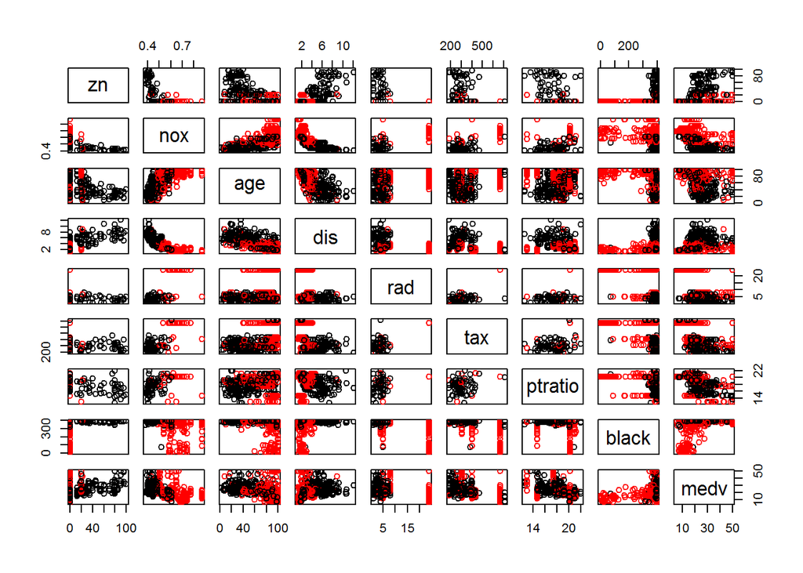

```r
pairs(~zn+nox+age+dis+rad+tax+ptratio+black+medv,data=Boston, col = cr+1)
```

Построим логистическую регрессию по этим признакам:

```r
log.full2 <- glm(cr~zn+nox+age+dis+rad+tax+ptratio+black+medv, data = Boston, family = binomial)
summary(log.full2)
```

```
##
## Call:
## glm(formula = cr ~ zn + nox + age + dis + rad + tax + ptratio +
##     black + medv, family = binomial, data = Boston)
##
## Deviance Residuals:
##     Min       1Q   Median       3Q      Max
## -2.4197  -0.1840  -0.0004   0.0022   3.4087
##
## Coefficients:
##               Estimate Std. Error z value Pr(>|z|)
## (Intercept) -31.441272   6.048989  -5.198 2.02e-07 ***
## zn           -0.082567   0.031424  -2.628  0.00860 **
## nox          43.195824   6.452812   6.694 2.17e-11 ***
## age           0.022851   0.009894   2.310  0.02091 *
## dis           0.634380   0.207634   3.055  0.00225 **
## rad           0.718773   0.142066   5.059 4.21e-07 ***
## tax          -0.007676   0.002503  -3.066  0.00217 **
## ptratio       0.303502   0.109255   2.778  0.00547 **
## black        -0.012866   0.006334  -2.031  0.04224 *
## medv          0.112882   0.034362   3.285  0.00102 **
## ---
## Signif. codes:  0 '***' 0.001 '**' 0.01 '*' 0.05 '.' 0.1 ' ' 1
##
## (Dispersion parameter for binomial family taken to be 1)
##
##     Null deviance: 701.46  on 505  degrees of freedom
## Residual deviance: 216.22  on 496  degrees of freedom
## AIC: 236.22
##
## Number of Fisher Scoring iterations: 9
```

Сделаем кросс-валидацию.

```r
library('boot')
1 - cv.glm(data.frame(cr, zn, nox, age, dis, rad, tax, ptratio, black, medv), log.full2, K = length(cr))$delta[1]
```

```
## [1] 0.9280047
```

Попробуем применить lasso. Зададим множество значений $\lambda$.

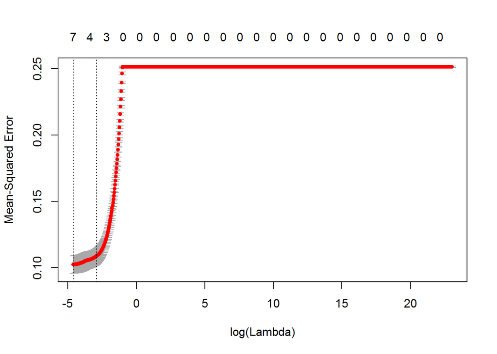

```r
grid <- 10^seq(10,-2,length=1000)
cv.res <- cv.glmnet(model.matrix(cr~zn+nox+age+dis+rad+tax+ptratio+black+medv, data = Boston)[, -1], cr, alpha = 1, lambda = grid)
plot(cv.res)
```

```r
cv.res$lambda.min
```

```
## [1] 0.01
```

Как видно, оптимальным значением $\lambda$ было выбрано минимальное заданное. Это говорит, что lasso применять не нужно.

Feature extraction: Попробуем выделить скрытые признаки с помощью главных компонент и построить по ним логистическую регрессию. Данные предварительно надо пронормировать, так как они измерены в разных шкалах,за это отвечает параметр scale.

```r
pk <- prcomp(Boston[,-1], scale. = TRUE)
```

Существует несколько общепризнанных методов отбора главных компонент, тут мы воспользуемся правилом Кайзера, так как у него есть тенденция завышать количество значимых компонент. Заключается он в сравнении дисперсий компонент со средним значением дисперсии, в нашем случае с 1.

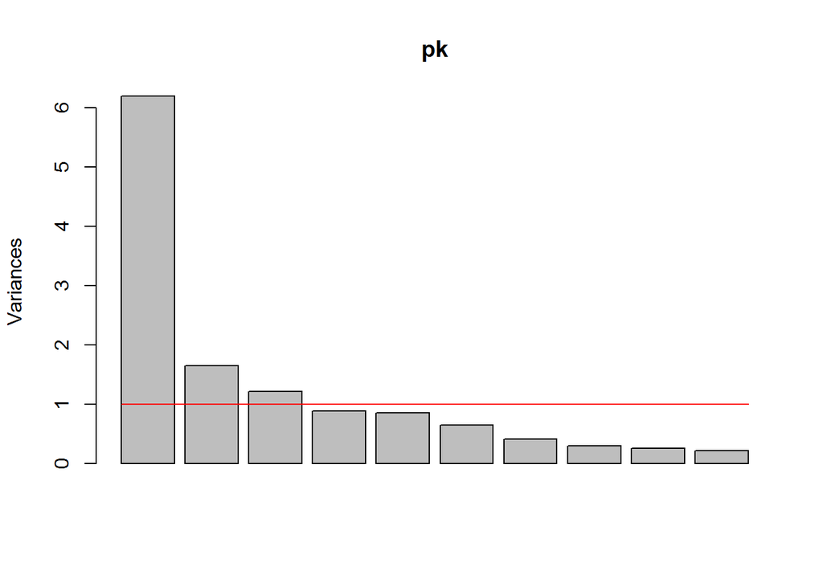

```r
plot(pk)
curve(1+0*x, add = TRUE, col = 'red')
```

Правило выбрало первые 3 главных компоненты. Посмотрим на них:

```r
pkx <- as.data.frame(cbind(cr, pk$x[,1:3]))
pkx[,1] <- as.factor(pkx[,1])
pk$rotation[,1:3]
```

```
##                  PC1         PC2         PC3
## zn      -0.260386431 -0.12232275  0.38678511
## indus    0.344970045  0.11705301 -0.01606480
## chas    -0.002537395  0.40537659 -0.20238642
## nox      0.337133326  0.24651528 -0.02428149
## rm      -0.212422422  0.45501084  0.33953869
## age      0.309700710  0.24541638 -0.20333926
## dis     -0.309928466 -0.34687275  0.16446671
## rad      0.303520488  0.05063099  0.47074769
## tax      0.327873512  0.02246586  0.41371570
## ptratio  0.214014884 -0.31923649  0.08428970
## black   -0.197245373  0.01096616 -0.43281439
## lstat    0.320591379 -0.21252009 -0.14991413
## medv    -0.274450582  0.45649295  0.12343134
```

```r
library('ggfortify')
```

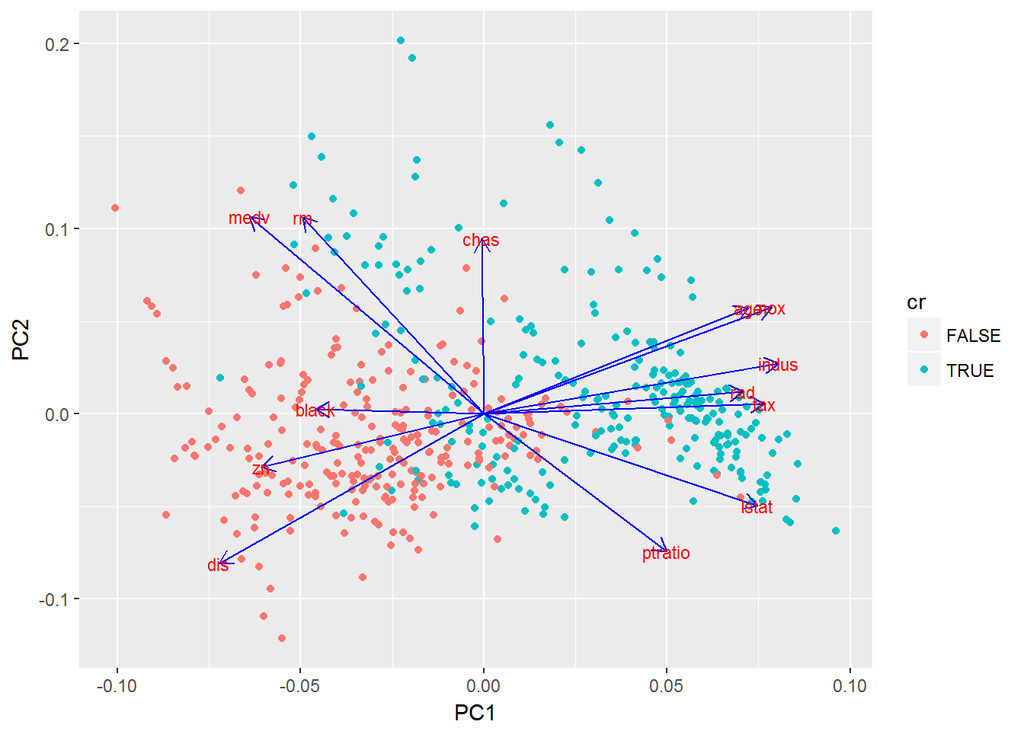

```r
autoplot(pk, data = cbind(cr, Boston[,-1]), colour = 'cr',
         loadings = TRUE,  loadings.colour = 'blue',
         loadings.label = TRUE, loadings.label.size = 3)
```

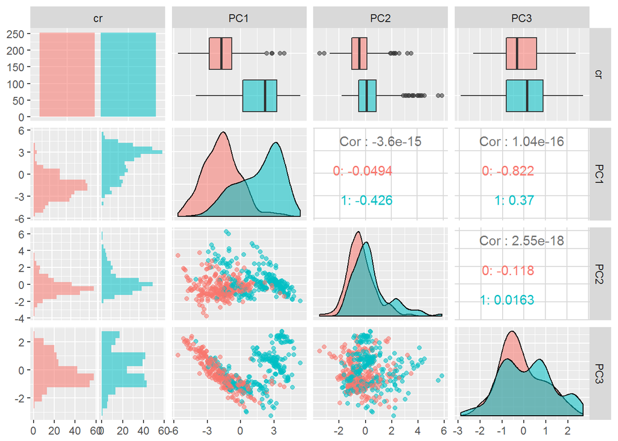

```r
library(GGally)
ggpairs(pkx, aes(colour = cr, alpha = 0.4), lower = list(combo = wrap(ggally_facethist, binwidth = 0.5)))
```

Построим по ним логистическую регрессию:

```r
log.full3 <- glm(cr~PC1+PC2+PC3, data = pkx, family = binomial)
summary(log.full3)
```

```
##
## Call:
## glm(formula = cr ~ PC1 + PC2 + PC3, family = binomial, data = pkx)
##
## Deviance Residuals:
##     Min       1Q   Median       3Q      Max
## -2.5520  -0.4919  -0.0369   0.2419   2.4398
##
## Coefficients:
##             Estimate Std. Error z value Pr(>|z|)
## (Intercept)   0.5096     0.2194   2.323 0.020171 *
## PC1           1.1393     0.1144   9.959  < 2e-16 ***
## PC2           0.8211     0.1192   6.889 5.63e-12 ***
## PC3           0.7307     0.2069   3.532 0.000412 ***
## ---
## Signif. codes:  0 '***' 0.001 '**' 0.01 '*' 0.05 '.' 0.1 ' ' 1
##
## (Dispersion parameter for binomial family taken to be 1)
##
##     Null deviance: 701.46  on 505  degrees of freedom
## Residual deviance: 323.50  on 502  degrees of freedom
## AIC: 331.5
##
## Number of Fisher Scoring iterations: 6
```

Как видим, все 3 компоненты оказались значимы. Проведем кросс-валидацию:

```r
1 - cv.glm(pkx, log.full3, K = length(cr))$delta[1]
```

```
## [1] 0.895055
```

получилось чуть хуже, однако предикторов всего 3.

# DA

Проведем теперь линейный дискриминантный анализ на наборе признаков, полученных с помощью AIC.

```r
library('klaR')
lda.full = lda(cr~zn+nox+age+dis+rad+tax+ptratio+black+medv, data = Boston)
lda.full
```

```
## Call:
## lda(cr ~ zn + nox + age + dis + rad + tax + ptratio + black +
##     medv, data = Boston)
##
## Prior probabilities of groups:
## FALSE  TRUE
##   0.5   0.5
##
## Group means:
##              zn       nox      age      dis       rad      tax  ptratio
## FALSE 21.525692 0.4709711 51.31028 5.091596  4.158103 305.7431 17.90711
## TRUE   1.201581 0.6384190 85.83953 2.498489 14.940711 510.7312 19.00395
##          black     medv
## FALSE 388.7061 24.94941
## TRUE  324.6420 20.11621
##
## Coefficients of linear discriminants:
##                   LD1
## zn      -0.0051859033
## nox      8.2897516233
## age      0.0125573120
## dis      0.0262347445
## rad      0.0713412560
## tax     -0.0005844197
## ptratio  0.0503048126
## black   -0.0011473668
## medv     0.0344836978
```

```r
mean(lda(cr~zn+nox+age+dis+rad+tax+ptratio+black+medv, data = Boston, CV=TRUE)$class == cr)
```

```
## [1] 0.8537549
```

Точность кроссвалидации ниже, чем при логистической регрессии.

Проведем пошаговый дискриминантный анализ, используя функцию greedy.wilks из пакета klaR:

```r
greedy.wilks(cr~.-crim, data = Boston, niveau = .1)
```

```
## Formula containing included variables:
##
## cr ~ nox + rad + age + medv + zn
## <environment: 0x000000001d1cfa68>
##
##
## Values calculated in each step of the selection procedure:
##
##   vars Wilks.lambda F.statistics.overall p.value.overall F.statistics.diff
## 1  nox    0.4769314             552.7557    4.585102e-83        552.755682
## 2  rad    0.4265729             338.0827    8.776145e-94         59.381045
## 3  age    0.4119561             238.8588    2.923009e-96         17.811693
## 4 medv    0.4013521             186.8201    7.277992e-98         13.236763
## 5   zn    0.3984572             150.9680    1.748082e-97          3.632618
##   p.value.diff
## 1 4.585102e-83
## 2 6.949996e-14
## 3 2.893944e-05
## 4 3.029155e-04
## 5 5.722962e-02
```

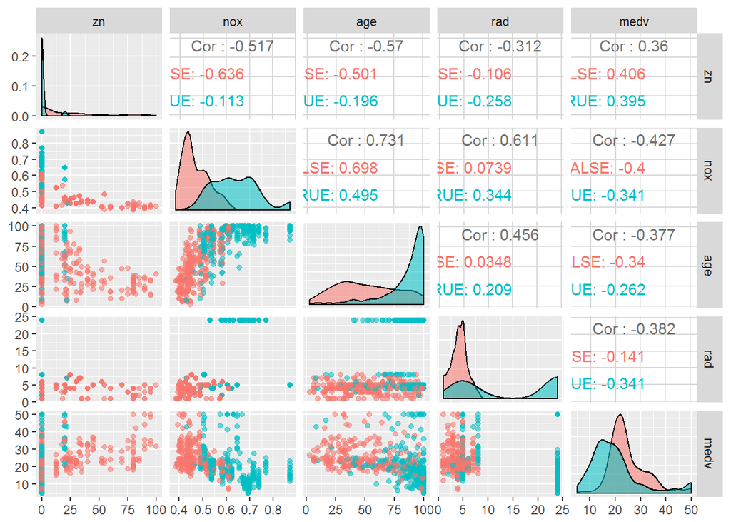

```r
f.cr <- as.factor(cr)
ggpairs(data.frame(f.cr, Boston), columns = c('zn', 'nox', 'age', 'rad', 'medv'), aes(colour = f.cr, alpha = 0.4), lower = list(combo = wrap(ggally_facethist, binwidth = 0.5)))
```

Процедура выявила пять признаков: nox, rad, age, medv, zn(p.value=0.057).

Проведем линейный дискриминантный анализ, используя эти признаки:

```r
lda.full2 = lda(cr~nox+rad+age+medv+zn, data = Boston)
lda.full2
```

```
## Call:
## lda(cr ~ nox + rad + age + medv + zn, data = Boston)
##
## Prior probabilities of groups:
## FALSE  TRUE
##   0.5   0.5
##
## Group means:
##             nox       rad      age     medv        zn
## FALSE 0.4709711  4.158103 51.31028 24.94941 21.525692
## TRUE  0.6384190 14.940711 85.83953 20.11621  1.201581
##
## Coefficients of linear discriminants:
##               LD1
## nox   7.632059762
## rad   0.071687938
## age   0.012071665
## medv  0.027953770
## zn   -0.005896697
```

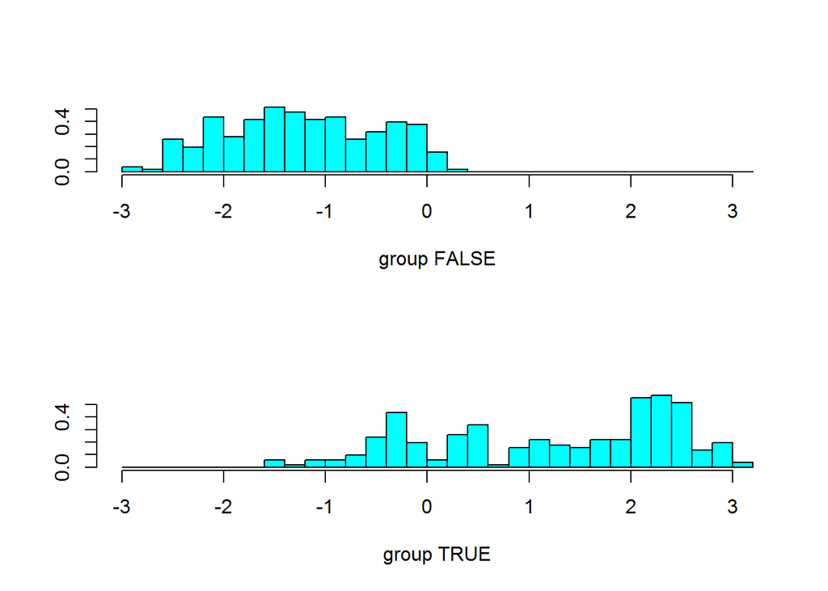

```r
plot(lda.full2)
```

Вспомним, что LDA для двух групп, по сути, является множественной регрессией $y = a + b_1x_1+\dots+b_nx_n$, где $b_i$ – коэффициенты дискриминантной функции, а $a=-\sum_{i=1}^nb_1\bar{x_i}$. Можем взять $y$ за новый признак и классифицировать по нему (LDA так и делает).

Чтобы понять, какой вклад вност каждый признак в новую дискриминантную переменную, рассмотрим стандартизованные дискриминантные функции:

```r
t(lda.full2$scaling * apply(Boston[,c('nox', 'rad', 'age', 'medv', 'zn')], 2, sd))
```

```
##           nox       rad       age      medv         zn
## LD1 0.8843853 0.6242055 0.3398036 0.2570937 -0.1375254
```

и факторную структуру(корреляции нового признака с исходными):

```r
disk <- apply(Boston[,c('nox', 'rad', 'age', 'medv', 'zn')], 1, function(x) sum(x*lda.full2$scaling))
apply(Boston[,c('nox', 'rad', 'age', 'medv', 'zn')], 2, function(x) cor(x, disk))
```

```
##        nox        rad        age       medv         zn
##  0.9324940  0.7991139  0.7915760 -0.3391174 -0.5623460
```

Можно заключить, что высокие значения nox, rad, age положительно влияют на уровень преступности.

Как и в случае с логистической регрессией, посмотрим, какова точность предсказания с помощью кросс-валидации:

```r
  cv.lda <- lda(cr~nox+rad+age+medv+zn, data = Boston, CV = TRUE)
  table(cv.lda$class, cr)
```

```
##        cr
##         FALSE TRUE
##   FALSE   244   59
##   TRUE      9  194
```

```r
  mean(cv.lda$class == cr)
```

```
## [1] 0.8656126
```

Результаты подтверждают, что предпосылки дискриминантного анализа не выполнены и логистическая регрессия лучше разделает группы.

Проведем теперь квадратичный дискриминантный анализ по признакам, полученным при пошаговом дискриминантном анализе.

```r
qda.full2 = qda(cr~nox+rad+age+medv+zn, data = Boston)
qda.full2
```

```
## Call:
## qda(cr ~ nox + rad + age + medv + zn, data = Boston)
##
## Prior probabilities of groups:
## FALSE  TRUE
##   0.5   0.5
##
## Group means:
##             nox       rad      age     medv        zn
## FALSE 0.4709711  4.158103 51.31028 24.94941 21.525692
## TRUE  0.6384190 14.940711 85.83953 20.11621  1.201581
```

```r
qda.full2$scaling
```

```
## , , FALSE
##
##             1          2           3            4           5
## nox  -17.9863 -1.3331591 17.58929842 -6.086882000 11.99755824
## rad    0.0000  0.6043822 -0.01425216 -0.075966906  0.03347905
## age    0.0000  0.0000000 -0.05400186 -0.005225672  0.00477364
## medv   0.0000  0.0000000  0.00000000 -0.152736336 -0.03107045
## zn     0.0000  0.0000000  0.00000000  0.000000000  0.04546920
##
## , , TRUE
##
##             1          2            3           4            5
## nox  10.13134 -3.7060770 -5.607006684 2.244518150 -1.426927539
## rad   0.00000  0.1117339 -0.005319321 0.028920432  0.017930178
## age   0.00000  0.0000000  0.064475282 0.006840814  0.008414046
## medv  0.00000  0.0000000  0.000000000 0.107672115 -0.037937601
## zn    0.00000  0.0000000  0.000000000 0.000000000  0.231627412
```

Применим кросс-валидацию:

```r
cv.qda <- qda(cr~nox+rad+age+medv+zn, data = Boston, CV = TRUE)
table(cv.qda$class, cr)
```

```
##        cr
##         FALSE TRUE
##   FALSE   223   46
##   TRUE     30  207
```

```r
mean(cv.qda$class == cr)
```

```
## [1] 0.8498024
```

Точность QDA почти такая же, как и у LDA, а вот баланс ошибок у QDA лучше.

# Regularized DA

Рассматривается такая модель: $\hat\Sigma_k(\lambda) = (1-\lambda)\hat\Sigma_k + \lambda\hat\Sigma.$

```r
rda.full <- klaR::rda(cr~nox+rad+age+medv+zn, data = Boston, crossval = TRUE, fold = length(cr), estimate.error = TRUE, gamma = 0)
rda.full$regularization
```

```
##     gamma    lambda
## 0.0000000 0.7571122
```

```r
1 - rda.full$error.rate[1]
```

```
##      APER
## 0.8675889
```

Регуляризация дала небольшое улучшение. Расширим модель: $\hat\Sigma_k(\lambda,\gamma) = (1-\gamma)\hat\Sigma_k(\lambda) + \gamma\frac{1}{d}trace(\hat\Sigma_k(\lambda)) I$.

```r
rda.full <- klaR::rda(cr~nox+rad+age+medv+zn, data = Boston, crossval = TRUE, fold = length(cr), estimate.error = TRUE)
rda.full$regularization
```

```
##        gamma       lambda
## 3.130727e-12 9.961268e-01
```

```r
1 - rda.full$error.rate[1]
```

```
##      APER
## 0.8656126
```